# Biblical Names Visualization

## Visualization & Result Part I: Biblical Names

### Overview:

In this section, we will include the visualization and result discussion for the analysis using biblical baby names.

(1) The first part of the analysis is using PC1 and PC2 of the cross-corelation matrix to separate the 51 states, and based on the projection of PC1, PC2 to choose the reasonable number of clusters. Then we uses Hierarchical Clustering, K-Means Clustering (related code in Hierarchical Clustering & K-Means Clustering section) to cluster 51 states.

(2) The visulization in this section includes (i) How to choose number of clusters (ii) Using Tableau to reflect the state-clusters in a map view (Tableau may not able to be shown in github, but it can be view on Ipython Notebook, and we will embed Tableau stories in the website)

```python
import pickle
import matplotlib
import numpy as np
import pandas as pd
import random
import matplotlib.cm as cmx
%matplotlib inline
from sklearn import preprocessing
import matplotlib.pyplot as plt
import matplotlib.colors as colors
from sklearn.decomposition import PCA
```

### Data processing

```python
f = open('data.pkl', 'rb')
dfList= pickle.load(f)
f.close()
```

```python
for i in yrs:
    dfList[i] = dfList[i].fillna(0)
```

```python
dfList[1914].head(5)
```

|  | Aaron | Abba | Abdi | Abdiel | Abdon | Abel | Abiel | Abigail | Abilene | Abner | ... | Zedekiah | Zemira | Zenas | Zephaniah | Zia | Zina | Zion | Zipporah | Zohar | Zorah |
| --- | --- | --- | --- | --- | --- | --- | --- | --- | --- | --- | --- | --- | --- | --- | --- | --- | --- | --- | --- | --- | --- |
| AK | 0 | 0 | 0 | 0 | 0 | 0 | 0 | 0 | 0 | 0 | ... | 0 | 0 | 0 | 0 | 0 | 0 | 0 | 0 | 0 | 0 |
| AL | 31 | 0 | 0 | 0 | 0 | 0 | 0 | 0 | 0 | 0 | ... | 0 | 0 | 0 | 0 | 0 | 0 | 0 | 0 | 0 | 0 |
| AR | 8 | 0 | 0 | 0 | 0 | 0 | 0 | 0 | 0 | 0 | ... | 0 | 0 | 0 | 0 | 0 | 0 | 0 | 0 | 0 | 0 |
| AZ | 0 | 0 | 0 | 0 | 0 | 0 | 0 | 0 | 0 | 0 | ... | 0 | 0 | 0 | 0 | 0 | 0 | 0 | 0 | 0 | 0 |
| CA | 6 | 0 | 0 | 0 | 0 | 0 | 0 | 0 | 0 | 0 | ... | 0 | 0 | 0 | 0 | 0 | 0 | 0 | 0 | 0 | 0 |

5 rows × 522 columns

```python
#51 states
dfList[1914].index
```

```
Index([u'AK', u'AL', u'AR', u'AZ', u'CA', u'CO', u'CT', u'DC', u'DE', u'FL',
       u'GA', u'HI', u'IA', u'ID', u'IL', u'IN', u'KS', u'KY', u'LA', u'MA',
       u'MD', u'ME', u'MI', u'MN', u'MO', u'MS', u'MT', u'NC', u'ND', u'NE',
       u'NH', u'NJ', u'NM', u'NV', u'NY', u'OH', u'OK', u'OR', u'PA', u'RI',
       u'SC', u'SD', u'TN', u'TX', u'UT', u'VA', u'VT', u'WA', u'WI', u'WV',
       u'WY'],
      dtype='object')
```

```python
#Function: corrstate: compute state by state corrleation between the fluctuations of the frequencies of the names over the states
#Input: df: dataframe has states as rows and biblical names as columns for each year
#Return: corr_matrix: matrix contains the Pearson correlation between the flucuations of name in state i and state j
#        for all states in the fluctuation;
def corrstate(df):
    #sum the count of name by states
    total_sum = df.sum(axis = 1)
    #divide the count of name in each state by the previous sum
    df1 = df.div(total_sum.ix[0],axis='columns')
    statenum = df1.shape[0]
    name_sum = df1.sum(axis = 0)
    #count the average frequency of name over the states
    averfreq = name_sum/float(statenum)
    #use the frequency of name in the state - average frequency of the name over states (he flucuations of name)
    fluctuation = df1.subtract(averfreq, axis ='columns')
    #compute the Pearson correlation among 51 states * 51 states
    return np.corrcoef(fluctuation)
```

```python
#Function: PCAcorr: use PC1, 2 to figure out the separate the noise from true system dynamics
#          Based on the assumption that the PC1, PC2 are related to true similarity
#Input: corr_matrix: Pearson correlation between the flucuations of name over states
#Return: corr_reduced: generated correlation matrix after reducing by PCA

def PCAcorr(corr_matrix):
    corr_matrix = preprocessing.normalize(corr_matrix)
    pca = PCA(n_components=2)
    pca.fit(corr_matrix)
    corr_reduced = pca.transform(corr_matrix)
    return corr_reduced
```

```python
#Function: convert the origianl correlation matrix into a positive definite matrix
#Input: corr_matrix: the origianl correlation matrix
#Return: converted correlation matrix
def converted_corr(corr_matrix):
    coverted_corr = (corr_matrix + 1)/2
    return coverted_corr
```

```python
PCA_1914 = PCAcorr(corrstate(dfList[1914]))
PCA_1918 = PCAcorr(corrstate(dfList[1918]))
PCA_1922 = PCAcorr(corrstate(dfList[1922]))
PCA_1926 = PCAcorr(corrstate(dfList[1926]))
PCA_1930 = PCAcorr(corrstate(dfList[1930]))
PCA_1934 = PCAcorr(corrstate(dfList[1934]))
PCA_1938 = PCAcorr(corrstate(dfList[1938]))
PCA_1942 = PCAcorr(corrstate(dfList[1942]))
PCA_1946 = PCAcorr(corrstate(dfList[1946]))
PCA_1950 = PCAcorr(corrstate(dfList[1950]))
PCA_1954 = PCAcorr(corrstate(dfList[1954]))
PCA_1958 = PCAcorr(corrstate(dfList[1958]))
PCA_1962 = PCAcorr(corrstate(dfList[1962]))
PCA_1966 = PCAcorr(corrstate(dfList[1966]))
PCA_1970 = PCAcorr(corrstate(dfList[1970]))
PCA_1974 = PCAcorr(corrstate(dfList[1974]))
PCA_1978 = PCAcorr(corrstate(dfList[1978]))
PCA_1982 = PCAcorr(corrstate(dfList[1982]))
PCA_1986 = PCAcorr(corrstate(dfList[1986]))
PCA_1990 = PCAcorr(corrstate(dfList[1990]))
PCA_1994 = PCAcorr(corrstate(dfList[1994]))
PCA_1998 = PCAcorr(corrstate(dfList[1998]))
```

```python
PCA=[]
PCA.append(PCA_1930)
PCA.append(PCA_1934)
PCA.append(PCA_1970)
PCA.append(PCA_1974)
PCA.append(PCA_1994)
PCA.append(PCA_1998)
```

### PC1, PC2 of Correlation matrix for 51 states over years

```python
#Function: Sort PC1 in descending order and assign each state a different color
#          Visualize the PC1,2 distribution for each state
#Input: pc12: Correlation matrix after reducing by PCA (which is based on the first two principle component of biblical names for each state)
#Input: title: the year that the data come from
#Input: i: column index for data visualization
#Input: ax_ind: row index for data visualizaion

def plot_pca_year_multi(pc12, title, i,ax_ind):
    # sort pca
    pc12=pc12[np.lexsort(([1,-1]*pc12[:,[1,0]]).T)]
    # split pc1, pc2
    pc1=pc12[:,0]
    pc2=pc12[:,1]
    # Plot data
    cs = matplotlib.cm.rainbow(np.linspace(0, 1, len(pc12)))
    ax[i][ax_ind].scatter(pc1,pc2,label='pc1 pc2',color=cs)
    # Label axes, set title
    ax[i][ax_ind].set_title(title,fontsize=15)
    ax[i][ax_ind].set_xlabel('$V^{(2)}$',fontsize=15)
    ax[i][ax_ind].set_ylabel('$V^{(1)}$',fontsize=15)
    ax[i][ax_ind].set_xlim(-1,1.5)
    ax[i][ax_ind].set_ylim(-1,1.5)
```

```python
yrs=[1930,1934,1970,1974,1994,1998]
```

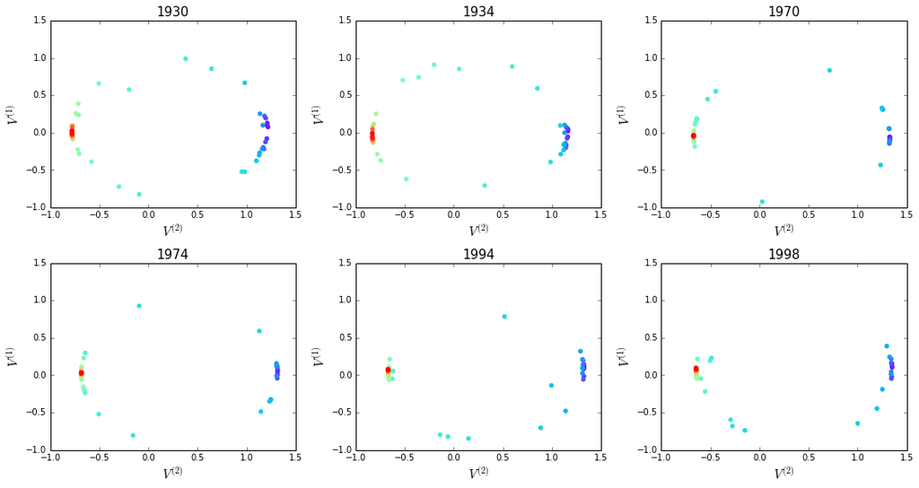

```python
fig, ax = plt.subplots(2, 3, figsize=(15,8 ))

#Start the index of the current subplot at 0
ax_ind = 0
ix=0
for j in range(0,2):
    ax_ind = j
    ix=ix
    #Iterate through all the shapes
    for i in range (0,3):
        pc12=PCA[ix]
        plot_pca_year_multi(pc12,str(yrs[ix]),ax_ind,i)
        ix+=1

plt.tight_layout()
plt.show()
```

**PC1PC2 visualization**

- We take the first two principle component from PCA for each year (which was calculated based on the matrices that consist of the correlation of distribution of biblical names in state I and and that in state j). And then we reorder the array (of the PC1, PC2) in the descending order of PC1 and then assign rainbow color.
- We found that there are 3 clusters (left, up/bottom, right) in every PC1/PC2 plots above for 6 different years. Therefore, we use 3 cluster for hierarchical clustering and K-means clustering to group states. States in the similar groups are going to be assigned similar colors in tableau visualization. The overlap between these points here could be used to describe the similarities between US states. Instead of considering these overlaps in time, we consider the correlations between states on a yearly basis, by studying the whole distribution of baby names that are biblical in every state.

### US map

```python
idx=['AK', 'AL', 'AR', 'AZ', 'CA', 'CO', 'CT', 'DC', 'DE', 'FL','GA', 'HI', 'IA', 'ID', 'IL', 'IN', 'KS', 'KY', 'LA', 'MA','MD', 'ME', 'MI', 'MN', 'MO', 'MS', 'MT', 'NC', 'ND', 'NE','NH', 'NJ', 'NM', 'NV', 'NY', 'OH', 'OK', 'OR', 'PA', 'RI','SC', 'SD', 'TN', 'TX', 'UT', 'VA', 'VT', 'WA', 'WI', 'WV','WY']
```

```python
yrs=[1930,1934,1970,1974,1994,1998]
```

```python
def generate_table(years,idx):
    n=len(years)
    j=0
    pc=PCA[j]
    df=pd.DataFrame(pc)
    df['idx']=idx
    df = df.set_index(['idx'])
    del df.index.name
    df.columns = ['pc1', 'pc2']
    sorted_df=df.sort('pc1',ascending=False)
    cs = matplotlib.cm.rainbow(np.linspace(0, 1, len(df)))
    color=cs[:,:-1]*255
    row=color.shape[0]
    new_color=[]

    for i in range(0,row):
        a=color[i]
        r=a[0]
        g=a[1]
        b=a[2]
        rgb=65536 * r + 256 * g + b
        new_color.append(rgb)

    YEAR=str(yrs[j])
    sorted_df[YEAR]=new_color
    table0=pd.DataFrame(sorted_df[YEAR])


    for j in range(1,n):
        pc=PCA[j]
        df=pd.DataFrame(pc)
        df['idx']=idx
        df = df.set_index(['idx'])
        del df.index.name
        df.columns = ['pc1', 'pc2']
        sorted_df=df.sort('pc1',ascending=False)
        cs = matplotlib.cm.rainbow(np.linspace(0, 1, len(df)))
        color=cs[:,:-1]*255
        row=color.shape[0]
        new_color=[]

        for i in range(0,row):
            a=color[i]
            r=a[0]
            g=a[1]
            b=a[2]
            rgb=65536 * r + 256 * g + b
            new_color.append(rgb)

        YEAR=str(yrs[j])
        sorted_df[YEAR]=new_color
        table1=pd.DataFrame(sorted_df[YEAR])
        table0=pd.concat([table0,table1],axis=1)


    return table0
```

```python
table=generate_table(yrs,idx)
table.head()
```

|  | 1930 | 1934 | 1970 | 1974 | 1994 | 1998 |
| --- | --- | --- | --- | --- | --- | --- |
| AK | 1.306817e+07 | 1.241440e+07 | 1.675332e+07 | 1.675634e+07 | 1.673151e+07 | 1.672370e+07 |
| AL | 1.709781e+06 | 2.361819e+06 | 4.419080e+06 | 4.419080e+06 | 5.075795e+06 | 6.388514e+06 |
| AR | 5.732275e+06 | 5.075795e+06 | 9.796999e+06 | 9.142040e+06 | 1.372171e+07 | 1.241440e+07 |
| AZ | 1.672370e+07 | 1.672370e+07 | 1.671168e+07 | 1.673902e+07 | 7.044510e+06 | 5.075795e+06 |
| CA | 2.361819e+06 | 1.709781e+06 | 3.795854e+06 | 4.447513e+06 | 3.144091e+06 | 4.447513e+06 |

```python
table.to_csv('color_tableau.csv')
```

```python
table=pd.read_csv("color_tableau.csv")
```

```python
writer = pd.ExcelWriter('color_tableau.xlsx', engine='xlsxwriter')
table.to_excel(writer, sheet_name='color',index = False,header=True)
writer.save()
```

### PCA result

```python
%%html
<div class='tableauPlaceholder' id='viz1481124829633' style='position: relative'><noscript><a href='#'><img alt='&lt;PCA results&gt; ' src='https:&#47;&#47;public.tableau.com&#47;static&#47;images&#47;hc&#47;hc_0&#47;Story3&#47;1_rss.png' style='border: none' /></a></noscript><object class='tableauViz'  style='display:none;'><param name='host_url' value='https%3A%2F%2Fpublic.tableau.com%2F' /> <param name='site_root' value='' /><param name='name' value='hc_0&#47;Story3' /><param name='tabs' value='no' /><param name='toolbar' value='yes' /><param name='static_image' value='https:&#47;&#47;public.tableau.com&#47;static&#47;images&#47;hc&#47;hc_0&#47;Story3&#47;1.png' /> <param name='animate_transition' value='yes' /><param name='display_static_image' value='yes' /><param name='display_spinner' value='yes' /><param name='display_overlay' value='yes' /><param name='display_count' value='yes' /></object></div>                <script type='text/javascript'>                    var divElement = document.getElementById('viz1481124829633');                    var vizElement = divElement.getElementsByTagName('object')[0];                    vizElement.style.width='1020px';vizElement.style.height='1033px';                    var scriptElement = document.createElement('script');                    scriptElement.src = 'https://public.tableau.com/javascripts/api/viz_v1.js';                    vizElement.parentNode.insertBefore(scriptElement, vizElement);                </script>
```

[figure not shown]

### Hierachical clustering

```python
HC=pd.read_csv("HC_results.csv")
#HC = HC.set_index(['state'])
#del HC.index.name
HC.head()
```

|  | state | 1910 | 1914 | 1918 | 1922 | 1926 | 1930 | 1934 | 1938 | 1942 | ... | 1962 | 1966 | 1970 | 1974 | 1978 | 1982 | 1986 | 1990 | 1994 | 1998 |
| --- | --- | --- | --- | --- | --- | --- | --- | --- | --- | --- | --- | --- | --- | --- | --- | --- | --- | --- | --- | --- | --- |
| 0 | AK | 1 | 2 | 0 | 2 | 2 | 2 | 1 | 2 | 1 | ... | 1 | 0 | 0 | 2 | 1 | 0 | 1 | 1 | 1 | 2 |
| 1 | AL | 2 | 0 | 1 | 0 | 0 | 1 | 2 | 0 | 0 | ... | 2 | 0 | 0 | 1 | 1 | 0 | 1 | 1 | 1 | 1 |
| 2 | AR | 0 | 1 | 1 | 1 | 0 | 0 | 0 | 1 | 2 | ... | 1 | 0 | 0 | 2 | 1 | 0 | 1 | 1 | 1 | 2 |
| 3 | AZ | 1 | 2 | 0 | 2 | 2 | 2 | 1 | 2 | 1 | ... | 1 | 0 | 0 | 2 | 1 | 0 | 1 | 1 | 1 | 1 |
| 4 | CA | 0 | 1 | 1 | 0 | 0 | 1 | 2 | 0 | 0 | ... | 0 | 2 | 2 | 0 | 2 | 2 | 2 | 2 | 2 | 0 |

5 rows × 23 columns

```python
HC_sub=HC[['state','1930','1934','1970','1974','1994','1998']]
HC_sub.head()
```

|  | state | 1930 | 1934 | 1970 | 1974 | 1994 | 1998 |
| --- | --- | --- | --- | --- | --- | --- | --- |
| 0 | AK | 2 | 1 | 0 | 2 | 1 | 2 |
| 1 | AL | 1 | 2 | 0 | 1 | 1 | 1 |
| 2 | AR | 0 | 0 | 0 | 2 | 1 | 2 |
| 3 | AZ | 2 | 1 | 0 | 2 | 1 | 1 |
| 4 | CA | 1 | 2 | 2 | 0 | 2 | 0 |

```python
writer = pd.ExcelWriter('HC_tableau.xlsx', engine='xlsxwriter')
HC_sub.to_excel(writer, sheet_name='HC')
writer.save()
```

### K means clustering

```python
KM=pd.read_csv("Kmeans_results.csv")
#KM = KM.set_index(['state'])
#del KM.index.name
KM.head()
```

|  | state | 1910 | 1914 | 1918 | 1922 | 1926 | 1930 | 1934 | 1938 | 1942 | ... | 1962 | 1966 | 1970 | 1974 | 1978 | 1982 | 1986 | 1990 | 1994 | 1998 |
| --- | --- | --- | --- | --- | --- | --- | --- | --- | --- | --- | --- | --- | --- | --- | --- | --- | --- | --- | --- | --- | --- |
| 0 | AK | 0 | 2 | 0 | 2 | 2 | 2 | 1 | 2 | 1 | ... | 1 | 0 | 0 | 2 | 1 | 0 | 1 | 1 | 1 | 2 |
| 1 | AL | 2 | 0 | 1 | 0 | 0 | 1 | 2 | 0 | 0 | ... | 2 | 0 | 0 | 1 | 1 | 0 | 1 | 1 | 1 | 1 |
| 2 | AR | 1 | 1 | 1 | 1 | 0 | 0 | 0 | 1 | 2 | ... | 1 | 0 | 0 | 2 | 1 | 0 | 1 | 1 | 1 | 2 |
| 3 | AZ | 0 | 2 | 0 | 2 | 2 | 2 | 1 | 2 | 1 | ... | 1 | 0 | 0 | 2 | 1 | 0 | 1 | 1 | 1 | 1 |
| 4 | CA | 1 | 1 | 1 | 0 | 0 | 1 | 2 | 0 | 0 | ... | 0 | 2 | 2 | 0 | 2 | 2 | 2 | 2 | 2 | 0 |

5 rows × 23 columns

```python
KM_sub=KM[['state','1930','1934','1970','1974','1994','1998']]
KM_sub.head()
```

|  | state | 1930 | 1934 | 1970 | 1974 | 1994 | 1998 |
| --- | --- | --- | --- | --- | --- | --- | --- |
| 0 | AK | 2 | 1 | 0 | 2 | 1 | 2 |
| 1 | AL | 1 | 2 | 0 | 1 | 1 | 1 |
| 2 | AR | 0 | 0 | 0 | 2 | 1 | 2 |
| 3 | AZ | 2 | 1 | 0 | 2 | 1 | 1 |
| 4 | CA | 1 | 2 | 2 | 0 | 2 | 0 |

```python
writer = pd.ExcelWriter('KM_tableau.xlsx', engine='xlsxwriter')
KM_sub.to_excel(writer, sheet_name='KM')
writer.save()
```

#### Hierachical clustering of the states

```python
%%html
<div class='tableauPlaceholder' id='viz1481124674276' style='position: relative'><noscript><a href='#'><img alt='&lt;Hierachical clustering results&gt; ' src='https:&#47;&#47;public.tableau.com&#47;static&#47;images&#47;hc&#47;hc_0&#47;Story1&#47;1_rss.png' style='border: none' /></a></noscript><object class='tableauViz'  style='display:none;'><param name='host_url' value='https%3A%2F%2Fpublic.tableau.com%2F' /> <param name='site_root' value='' /><param name='name' value='hc_0&#47;Story1' /><param name='tabs' value='no' /><param name='toolbar' value='yes' /><param name='static_image' value='https:&#47;&#47;public.tableau.com&#47;static&#47;images&#47;hc&#47;hc_0&#47;Story1&#47;1.png' /> <param name='animate_transition' value='yes' /><param name='display_static_image' value='yes' /><param name='display_spinner' value='yes' /><param name='display_overlay' value='yes' /><param name='display_count' value='yes' /></object></div>                <script type='text/javascript'>                    var divElement = document.getElementById('viz1481124674276');                    var vizElement = divElement.getElementsByTagName('object')[0];                    vizElement.style.width='1020px';vizElement.style.height='1033px';                    var scriptElement = document.createElement('script');                    scriptElement.src = 'https://public.tableau.com/javascripts/api/viz_v1.js';                    vizElement.parentNode.insertBefore(scriptElement, vizElement);                </script>
```

[figure not shown]

#### K means clustering

```python
%%html
<div class='tableauPlaceholder' id='viz1481124766216' style='position: relative'><noscript><a href='#'><img alt='&lt;K-MEANS clustering results&gt; ' src='https:&#47;&#47;public.tableau.com&#47;static&#47;images&#47;hc&#47;hc_0&#47;Story2&#47;1_rss.png' style='border: none' /></a></noscript><object class='tableauViz'  style='display:none;'><param name='host_url' value='https%3A%2F%2Fpublic.tableau.com%2F' /> <param name='site_root' value='' /><param name='name' value='hc_0&#47;Story2' /><param name='tabs' value='no' /><param name='toolbar' value='yes' /><param name='static_image' value='https:&#47;&#47;public.tableau.com&#47;static&#47;images&#47;hc&#47;hc_0&#47;Story2&#47;1.png' /> <param name='animate_transition' value='yes' /><param name='display_static_image' value='yes' /><param name='display_spinner' value='yes' /><param name='display_overlay' value='yes' /><param name='display_count' value='yes' /></object></div>                <script type='text/javascript'>                    var divElement = document.getElementById('viz1481124766216');                    var vizElement = divElement.getElementsByTagName('object')[0];                    vizElement.style.width='1020px';vizElement.style.height='1033px';                    var scriptElement = document.createElement('script');                    scriptElement.src = 'https://public.tableau.com/javascripts/api/viz_v1.js';                    vizElement.parentNode.insertBefore(scriptElement, vizElement);                </script>
```

[figure not shown]

**Graphing maps**

- Before using Tableau to generate the colorful US map, we convert the 3 digit RGB color to 1-digit number using a formula. Thus, the color assigned to the states reflect the similarity in their distributions of biblical names.
- For both hieratical clustering and K means clustering results, the three color assigned to the states reflect the similarity in their distributions of names. After 1970, the states in the east coast are more diverse. We use a notion of similarity based on the matrices of states correlations. Data shown in this figure have been obtained looking at both baby girl and baby boy names.
- This analysis clearly shows that north-western groups of states form well-separated clusters while north-eastern groups of states form not well-separated clusters over years. The social evolution of geographical correlation showing that as time goes by, the Christianity affiliation in the east coast become more diversified than the west coast.

# Exploring whether Christianity related social events are related to the change in state-state relationship

Since we use biblical names to quantify the state-state relationship and noticed there are changed in the state-state relationship over time, we wonder whether there are some major Christianity related social events causes these changes in the relationship.

We select two possible major Christianity related event: civil war and Separation of church and state.

Civil war: Rev. Martin Luther King, Jr. was but one of many notable Black ministers involved in the movement. He helped found the Southern Christian Leadership Conference (1957), serving as its first president.

Separation of church and state: In October 1801, members of the Danbury Baptists Associations wrote a letter to the new president-elect Thomas Jefferson. Baptists, being a minority in Connecticut, were still required to pay fees to support the Congregationalist majority. The Baptists found this intolerable. The Baptists, well aware of Jefferson's own unorthodox beliefs, sought him as an ally in making all religious expression a fundamental human right and not a matter of government largesse.

However, those events are in relatively small scales (may not to able to reflected in the state scale) and there are no large Christianity related social events. We have more analysis focus on the all baby names in Visulization section II.

### Before and After civil war:

#### HC

```python
HC=pd.read_csv("new_HC.csv")
HC.head()
```

|  | state | civil_before | civil_after | separate_before | separate_after |
| --- | --- | --- | --- | --- | --- |
| 0 | AK | 3 | 2 | 3 | 3 |
| 1 | AL | 2 | 0 | 0 | 2 |
| 2 | AR | 1 | 2 | 1 | 3 |
| 3 | AZ | 3 | 2 | 3 | 3 |
| 4 | CA | 0 | 3 | 2 | 0 |

```python
writer = pd.ExcelWriter('new_HC_tableau.xlsx', engine='xlsxwriter')
HC.to_excel(writer, sheet_name='new_HC')
writer.save()
```

```python
%%html
<div class='tableauPlaceholder' id='viz1481489118120' style='position: relative'><noscript><a href='#'><img alt='&lt;HC - Before and After civil war&gt; ' src='https:&#47;&#47;public.tableau.com&#47;static&#47;images&#47;7X&#47;7X3JXNQXM&#47;1_rss.png' style='border: none' /></a></noscript><object class='tableauViz'  style='display:none;'><param name='host_url' value='https%3A%2F%2Fpublic.tableau.com%2F' /> <param name='path' value='shared&#47;7X3JXNQXM' /> <param name='toolbar' value='yes' /><param name='static_image' value='https:&#47;&#47;public.tableau.com&#47;static&#47;images&#47;7X&#47;7X3JXNQXM&#47;1.png' /> <param name='animate_transition' value='yes' /><param name='display_static_image' value='yes' /><param name='display_spinner' value='yes' /><param name='display_overlay' value='yes' /><param name='display_count' value='yes' /></object></div>                <script type='text/javascript'>                    var divElement = document.getElementById('viz1481489118120');                    var vizElement = divElement.getElementsByTagName('object')[0];                    vizElement.style.width='1020px';vizElement.style.height='1033px';                    var scriptElement = document.createElement('script');                    scriptElement.src = 'https://public.tableau.com/javascripts/api/viz_v1.js';                    vizElement.parentNode.insertBefore(scriptElement, vizElement);                </script>
```

[figure not shown]

#### K means

```python
KM=pd.read_csv("new_Kmeans.csv")
KM.head()
```

|  | state | civil_before | civil_after | separate_before | separate_after |
| --- | --- | --- | --- | --- | --- |
| 0 | AK | 0 | 0 | 1 | 2 |
| 1 | AL | 2 | 2 | 2 | 3 |
| 2 | AR | 0 | 0 | 3 | 2 |
| 3 | AZ | 0 | 0 | 1 | 2 |
| 4 | CA | 1 | 1 | 0 | 1 |

```python
writer = pd.ExcelWriter('new_KM_tableau.xlsx', engine='xlsxwriter')
KM.to_excel(writer, sheet_name='new_KM')
writer.save()
```

```python
%%html
<div class='tableauPlaceholder' id='viz1481489184186' style='position: relative'><noscript><a href='#'><img alt='&lt;KM - Before and After Civil war&gt; ' src='https:&#47;&#47;public.tableau.com&#47;static&#47;images&#47;ne&#47;new_56&#47;Story2&#47;1_rss.png' style='border: none' /></a></noscript><object class='tableauViz'  style='display:none;'><param name='host_url' value='https%3A%2F%2Fpublic.tableau.com%2F' /> <param name='site_root' value='' /><param name='name' value='new_56&#47;Story2' /><param name='tabs' value='no' /><param name='toolbar' value='yes' /><param name='static_image' value='https:&#47;&#47;public.tableau.com&#47;static&#47;images&#47;ne&#47;new_56&#47;Story2&#47;1.png' /> <param name='animate_transition' value='yes' /><param name='display_static_image' value='yes' /><param name='display_spinner' value='yes' /><param name='display_overlay' value='yes' /><param name='display_count' value='yes' /></object></div>                <script type='text/javascript'>                    var divElement = document.getElementById('viz1481489184186');                    var vizElement = divElement.getElementsByTagName('object')[0];                    vizElement.style.width='1020px';vizElement.style.height='1033px';                    var scriptElement = document.createElement('script');                    scriptElement.src = 'https://public.tableau.com/javascripts/api/viz_v1.js';                    vizElement.parentNode.insertBefore(scriptElement, vizElement);                </script>
```

[figure not shown]

### Before and After seperation of church and state

#### HC

```python
%%html
<div class='tableauPlaceholder' id='viz1481489495958' style='position: relative'><noscript><a href='#'><img alt='&lt;HC - Before and After Church State separation&gt; ' src='https:&#47;&#47;public.tableau.com&#47;static&#47;images&#47;ne&#47;new_56&#47;Story3&#47;1_rss.png' style='border: none' /></a></noscript><object class='tableauViz'  style='display:none;'><param name='host_url' value='https%3A%2F%2Fpublic.tableau.com%2F' /> <param name='site_root' value='' /><param name='name' value='new_56&#47;Story3' /><param name='tabs' value='no' /><param name='toolbar' value='yes' /><param name='static_image' value='https:&#47;&#47;public.tableau.com&#47;static&#47;images&#47;ne&#47;new_56&#47;Story3&#47;1.png' /> <param name='animate_transition' value='yes' /><param name='display_static_image' value='yes' /><param name='display_spinner' value='yes' /><param name='display_overlay' value='yes' /><param name='display_count' value='yes' /></object></div>                <script type='text/javascript'>                    var divElement = document.getElementById('viz1481489495958');                    var vizElement = divElement.getElementsByTagName('object')[0];                    vizElement.style.width='1020px';vizElement.style.height='1033px';                    var scriptElement = document.createElement('script');                    scriptElement.src = 'https://public.tableau.com/javascripts/api/viz_v1.js';                    vizElement.parentNode.insertBefore(scriptElement, vizElement);                </script>
```

[figure not shown]

#### KM

```python
%%html
<div class='tableauPlaceholder' id='viz1481489415852' style='position: relative'><noscript><a href='#'><img alt='&lt;KM - Before and After Church State separation&gt; ' src='https:&#47;&#47;public.tableau.com&#47;static&#47;images&#47;ne&#47;new_56&#47;Story4&#47;1_rss.png' style='border: none' /></a></noscript><object class='tableauViz'  style='display:none;'><param name='host_url' value='https%3A%2F%2Fpublic.tableau.com%2F' /> <param name='site_root' value='' /><param name='name' value='new_56&#47;Story4' /><param name='tabs' value='no' /><param name='toolbar' value='yes' /><param name='static_image' value='https:&#47;&#47;public.tableau.com&#47;static&#47;images&#47;ne&#47;new_56&#47;Story4&#47;1.png' /> <param name='animate_transition' value='yes' /><param name='display_static_image' value='yes' /><param name='display_spinner' value='yes' /><param name='display_overlay' value='yes' /><param name='display_count' value='yes' /></object></div>                <script type='text/javascript'>                    var divElement = document.getElementById('viz1481489415852');                    var vizElement = divElement.getElementsByTagName('object')[0];                    vizElement.style.width='1020px';vizElement.style.height='1033px';                    var scriptElement = document.createElement('script');                    scriptElement.src = 'https://public.tableau.com/javascripts/api/viz_v1.js';                    vizElement.parentNode.insertBefore(scriptElement, vizElement);                </script>
```

[figure not shown]